# CODEBOOK

Tingting

7 5 2019

## https://github.com/rubenarslan/codebook

## Generate markdown codebooks from the attributes of the variables in data frame

```r
knitr::opts_chunk$set(
  warning = TRUE, # show warnings during codebook generation
  message = TRUE, # show messages during codebook generation
  error = TRUE, # do not interrupt codebook generation in case of errors,
                # usually makes debugging easier, and sometimes half a codebook
                # is better than none
  echo = FALSE  # don't show the R code
)
ggplot2::theme_set(ggplot2::theme_bw())
pander::panderOptions("table.split.table", Inf)

load("C:/Users/tingtinf/Downloads/t1.RData")
codebook_data = t1
```

##Sometimes, the metadata is not set up in such a way that codebook can leverage it fully. These functions help fix this.

# If you are not using formr, the codebook package needs to guess which items

# form a scale. The following line finds item aggregates with names like this:

# scale = scale_1 + scale_2R + scale_3R

# identifying these aggregates allows the codebook function to

# automatically compute reliabilities.

# However, it will not reverse items automatically.

#generating a codebook is as simple as calling codebook from a chunk in an rmarkdown document.

```
## No missing values.
```

### Metadata

#### Description

**Dataset name**: codebook_data

The dataset has N=205 rows and 9 columns. 205 rows have no missing values on any column.

**Metadata for search engines**

- **Date published**: 2019-05-07
  - **keywords**: *time*, *status*, *sex*, *age*, *year*, *thickness*, *ulcer*, *exit.date* and *site*

## Variables

### time

#### Distribution

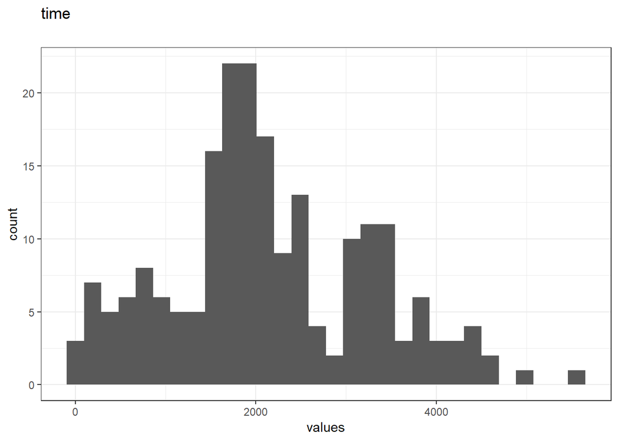

0 missing values.

#### Summary statistics

| name | data_type | missing | complete | n | mean | sd | p0 | p25 | p50 | p75 | p100 | hist |
| --- | --- | --- | --- | --- | --- | --- | --- | --- | --- | --- | --- | --- |
| time | integer | 0 | 205 | 205 | 2152.8 | 1122.06 | 10 | 1525 | 2005 | 3042 | 5565 | ▂▂▇▅▃▂▁▁ |

### status

#### Distribution

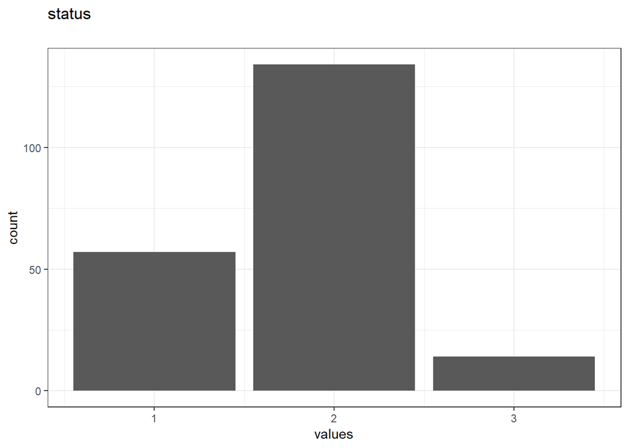

0 missing values.

#### Summary statistics

| name | data_type | missing | complete | n | mean | sd | p0 | p25 | p50 | p75 | p100 | hist |
| --- | --- | --- | --- | --- | --- | --- | --- | --- | --- | --- | --- | --- |
| status | integer | 0 | 205 | 205 | 1.79 | 0.55 | 1 | 1 | 2 | 2 | 3 | ▃▁▁▇▁▁▁▁ |

### sex

#### Distribution

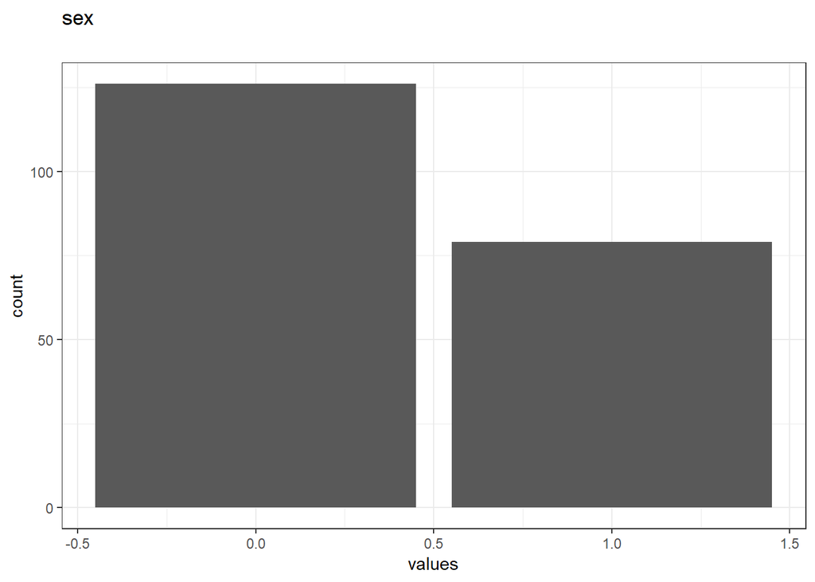

0 missing values.

#### Summary statistics

| name | data_type | missing | complete | n | mean | sd | p0 | p25 | p50 | p75 | p100 | hist |
| --- | --- | --- | --- | --- | --- | --- | --- | --- | --- | --- | --- | --- |
| sex | integer | 0 | 205 | 205 | 0.39 | 0.49 | 0 | 0 | 0 | 1 | 1 | ▇▁▁▁▁▁▁▅ |

### age

#### Distribution

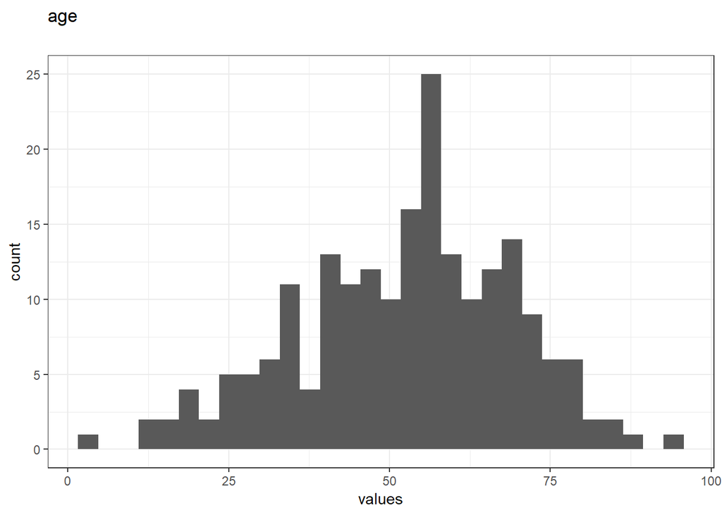

0 missing values.

#### Summary statistics

| name | data_type | missing | complete | n | mean | sd | p0 | p25 | p50 | p75 | p100 | hist |
| --- | --- | --- | --- | --- | --- | --- | --- | --- | --- | --- | --- | --- |
| age | integer | 0 | 205 | 205 | 52.46 | 16.67 | 4 | 42 | 54 | 65 | 95 | ▁▂▃▆▇▇▂▁ |

### year

#### Distribution

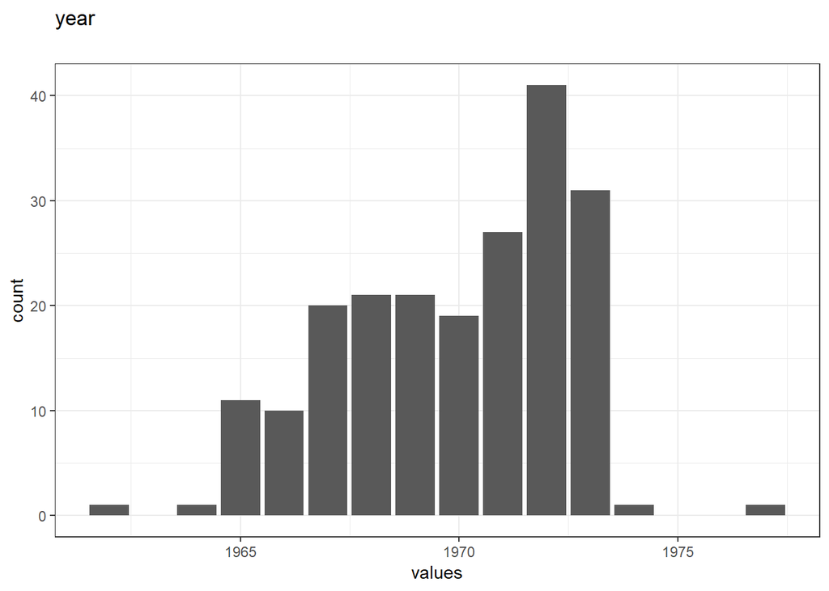

0 missing values.

#### Summary statistics

| name | data_type | missing | complete | n | mean | sd | p0 | p25 | p50 | p75 | p100 | hist |
| --- | --- | --- | --- | --- | --- | --- | --- | --- | --- | --- | --- | --- |
| year | integer | 0 | 205 | 205 | 1969.91 | 2.58 | 1962 | 1968 | 1970 | 1972 | 1977 | ▁▁▃▅▅▇▁▁ |

### thickness

#### Distribution

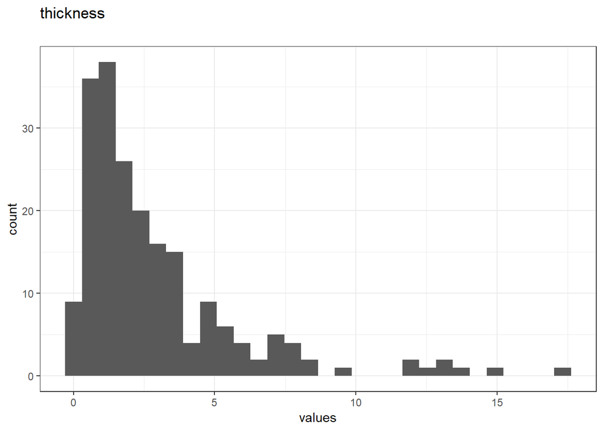

0 missing values.

#### Summary statistics

| name | data_type | missing | complete | n | mean | sd | p0 | p25 | p50 | p75 | p100 | hist |
| --- | --- | --- | --- | --- | --- | --- | --- | --- | --- | --- | --- | --- |
| thickness | numeric | 0 | 205 | 205 | 2.92 | 2.96 | 0.1 | 0.97 | 1.94 | 3.56 | 17.42 | ▇▃▂▁▁▁▁▁ |

### ulcer

#### Distribution

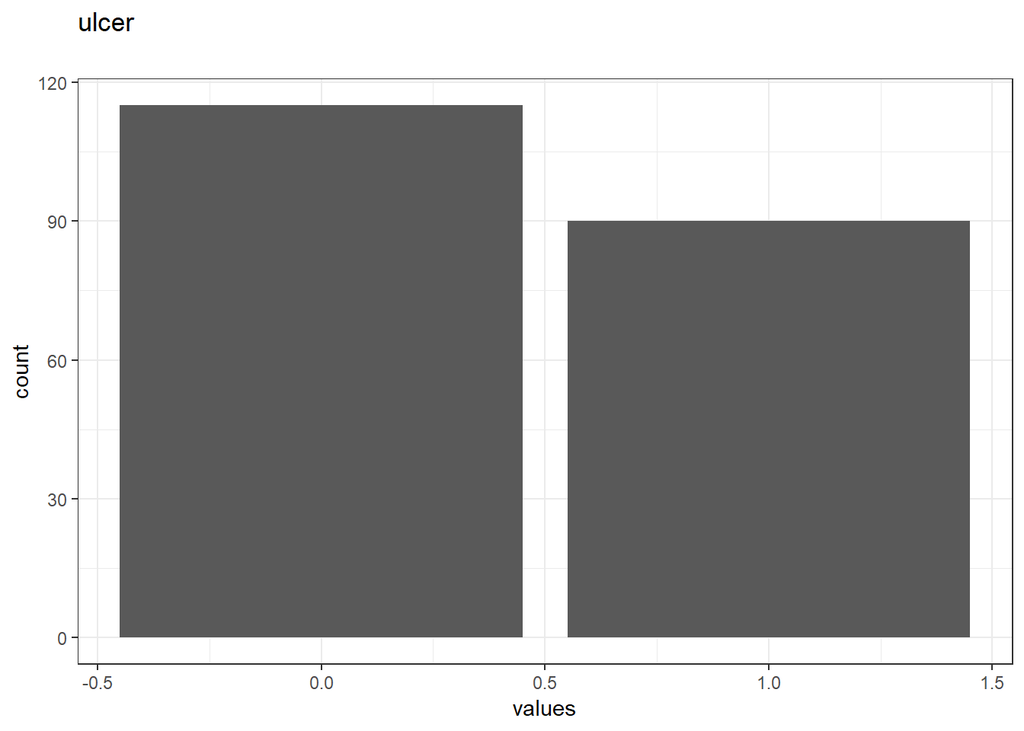

0 missing values.

#### Summary statistics

| name | data_type | missing | complete | n | mean | sd | p0 | p25 | p50 | p75 | p100 | hist |
| --- | --- | --- | --- | --- | --- | --- | --- | --- | --- | --- | --- | --- |
| ulcer | integer | 0 | 205 | 205 | 0.44 | 0.5 | 0 | 0 | 0 | 1 | 1 | ▇▁▁▁▁▁▁▆ |

### exit.date

#### Distribution

```
## 205  unique, categorical values, so not shown.
```

0 missing values.

#### Summary statistics

| name | data_type | missing | complete | n | n_unique | median | min | max |
| --- | --- | --- | --- | --- | --- | --- | --- | --- |
| exit.date | Date | 0 | 205 | 205 | 205 | 1999-07-02 | 1999-01-01 | 2000-01-01 |

### site

#### Distribution

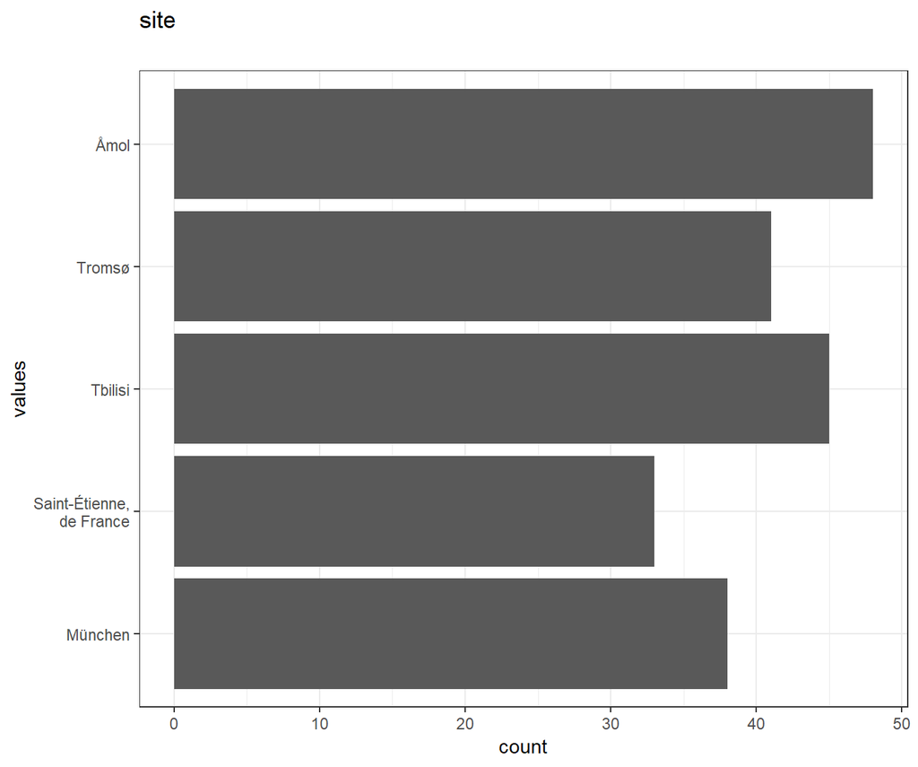

0 missing values.

#### Summary statistics

| name | data_type | missing | complete | n | empty | n_unique | min | max |
| --- | --- | --- | --- | --- | --- | --- | --- | --- |
| site | character | 0 | 205 | 205 | 0 | 5 | 4 | 24 |

## Codebook table

| name | data_type | missing | complete | n | empty | n_unique | median | min | max | mean | sd | p0 | p25 | p50 | p75 | p100 | hist |
| --- | --- | --- | --- | --- | --- | --- | --- | --- | --- | --- | --- | --- | --- | --- | --- | --- | --- |
| time | integer | 0 | 205 | 205 |  |  |  |  |  | 2152.8 | 1122.06 | 10 | 1525 | 2005 | 3042 | 5565 | ▂▂▇▅▃▂▁▁ |
| status | integer | 0 | 205 | 205 |  |  |  |  |  | 1.79 | 0.55 | 1 | 1 | 2 | 2 | 3 | ▃▁▁▇▁▁▁▁ |
| sex | integer | 0 | 205 | 205 |  |  |  |  |  | 0.39 | 0.49 | 0 | 0 | 0 | 1 | 1 | ▇▁▁▁▁▁▁▅ |
| age | integer | 0 | 205 | 205 |  |  |  |  |  | 52.46 | 16.67 | 4 | 42 | 54 | 65 | 95 | ▁▂▃▆▇▇▂▁ |
| year | integer | 0 | 205 | 205 |  |  |  |  |  | 1969.91 | 2.58 | 1962 | 1968 | 1970 | 1972 | 1977 | ▁▁▃▅▅▇▁▁ |
| thickness | numeric | 0 | 205 | 205 |  |  |  |  |  | 2.92 | 2.96 | 0.1 | 0.97 | 1.94 | 3.56 | 17.42 | ▇▃▂▁▁▁▁▁ |
| ulcer | integer | 0 | 205 | 205 |  |  |  |  |  | 0.44 | 0.5 | 0 | 0 | 0 | 1 | 1 | ▇▁▁▁▁▁▁▆ |
| exit.date | Date | 0 | 205 | 205 |  | 205 | 1999-07-02 | 1999-01-01 | 2000-01-01 |  |  |  |  |  |  |  |  |
| site | character | 0 | 205 | 205 | 0 | 5 |  | 4 | 24 |  |  |  |  |  |  |  |  |

**JSON-LD metadata**

The following JSON-LD can be found by search engines, if you share this codebook publicly on the web.

```json
{
  "name": "codebook_data",
  "datePublished": "2019-05-07",
  "description": "The dataset has N=205 rows and 9 columns.\n205 rows have no missing values on any column.\n\n\n## Table of variables\nThis table contains variable names, labels, their central tendencies and other attributes.\n\n|name      |data_type |missing |complete |n   |empty |n_unique |median     |min        |max        |mean    |sd      |p0   |p25  |p50  |p75  |p100  |hist     |\n|:---------|:---------|:-------|:--------|:---|:-----|:--------|:----------|:----------|:----------|:-------|:-------|:----|:----|:----|:----|:-----|:--------|\n|time      |integer   |0       |205      |205 |NA    |NA       |NA         |NA         |NA         |2152.8  |1122.06 |10   |1525 |2005 |3042 |5565  |▂▂▇▅▃▂▁▁ |\n|status    |integer   |0       |205      |205 |NA    |NA       |NA         |NA         |NA         |1.79    |0.55    |1    |1    |2    |2    |3     |▃▁▁▇▁▁▁▁ |\n|sex       |integer   |0       |205      |205 |NA    |NA       |NA         |NA         |NA         |0.39    |0.49    |0    |0    |0    |1    |1     |▇▁▁▁▁▁▁▅ |\n|age       |integer   |0       |205      |205 |NA    |NA       |NA         |NA         |NA         |52.46   |16.67   |4    |42   |54   |65   |95    |▁▂▃▆▇▇▂▁ |\n|year      |integer   |0       |205      |205 |NA    |NA       |NA         |NA         |NA         |1969.91 |2.58    |1962 |1968 |1970 |1972 |1977  |▁▁▃▅▅▇▁▁ |\n|thickness |numeric   |0       |205      |205 |NA    |NA       |NA         |NA         |NA         |2.92    |2.96    |0.1  |0.97 |1.94 |3.56 |17.42 |▇▃▂▁▁▁▁▁ |\n|ulcer     |integer   |0       |205      |205 |NA    |NA       |NA         |NA         |NA         |0.44    |0.5     |0    |0    |0    |1    |1     |▇▁▁▁▁▁▁▆ |\n|exit.date |Date      |0       |205      |205 |NA    |205      |1999-07-02 |1999-01-01 |2000-01-01 |NA      |NA      |NA   |NA   |NA   |NA   |NA    |NA       |\n|site      |character |0       |205      |205 |0     |5        |NA         |4          |24         |NA      |NA      |NA   |NA   |NA   |NA   |NA    |NA       |\n\n### Note\nThis dataset was automatically described using the [codebook R package](https://rubenarslan.github.io/codebook/) (version 0.8.0).",
  "keywords": ["time", "status", "sex", "age", "year", "thickness", "ulcer", "exit.date", "site"],
  "@context": "http://schema.org/",
  "@type": "Dataset",
  "variableMeasured": [
    {
      "name": "time",
      "@type": "propertyValue"
    },
    {
      "name": "status",
      "@type": "propertyValue"
    },
    {
      "name": "sex",
      "@type": "propertyValue"
    },
    {
      "name": "age",
      "@type": "propertyValue"
    },
    {
      "name": "year",
      "@type": "propertyValue"
    },
    {
      "name": "thickness",
      "@type": "propertyValue"
    },
    {
      "name": "ulcer",
      "@type": "propertyValue"
    },
    {
      "name": "exit.date",
      "@type": "propertyValue"
    },
    {
      "name": "site",
      "@type": "propertyValue"
    }
  ]
}`
```